# Clash_Royale_Portfolio_Analysis

Anthony Amit Biswas - 3461012

2025-11-14

# 1. Introduction

**Clash Royale and Performance Analysis**

This assignment investigates the relationship between player psychology, time investment, and performance outcomes in **Clash Royale**, a popular real-time strategy mobile game developed and published by **Supercell.**

[figure not shown]

Clash Royale is a free-to-play, competitive multiplayer game that successfully merges elements of **collectible card games** (CCG), **tower defense**, and **multiplayer online battle arena** (MOBA). The primary objective of the game is to destroy more of the opponent’s towers than they destroy of yours within a set time limit, primarily by deploying various **cards** (troops, spells, and buildings)

[figure not shown]

**Game Mechanics and Performance**

The core measure of progression and skill in Clash Royale is the **Trophy Count.**

[figure not shown]

which determines a player’s standing and their access to higher-level competitive **Arenas**. The daily change in this count (Trophy Gain/Loss) is a direct measure of daily success.

The performance of a player is heavily influenced by three factors explored in this study:

1. **Strategic Investment (Hours Played):** The time a player dedicates to the game .
2. **Performance Outcome (Win Rate):** The percentage of matches won, which directly drives trophy progression.
3. **Psychological State (Mood):** The player’s self-reported emotional state, which is hypothesized to influence decision-making and overall performance quality

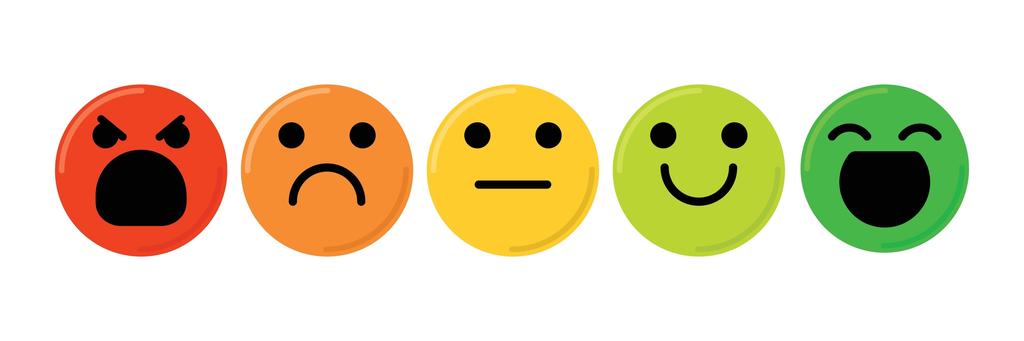

This project uses **statistical analysis**—specifically $t$-tests, linear/logistic regression, and $\chi^2$ tests—on a personal dataset to empirically determine which of these factors has the most significant impact on daily success and trophy progression in Clash Royale .

## 1.1 Dataset Description and Origin

The data used in this portfolio is a small, personally collected dataset tracking my daily performance in the mobile game, **Clash Royale**, over a 30-day period. This dataset serves as a relevant ‘day-to-day life’ example to analyze how various internal (e.g., mood) and external factors (e.g., time spent) influence my in-game success, measured by **Win Rate** and **Trophy Gain**. The data was manually recorded from the in-game battle log and profile screen.

## 1.2 Data Loading and Inspection

The data file, `Clash_Royale_Dataset.csv`, is loaded, and new variables are generated to facilitate hypothesis testing. The first six lines are displayed below, as required by the portfolio brief, to show the variables used and the extent of the data.

```r
# Loading the data
data_cr <- read_csv("Clash_Royale_Dataset.csv")

# 1. Calculating Trophy_Gain (Crucial for Linear Regression)
# This finds the difference in trophies from the previous day.
data_cr <- data_cr %>%
  mutate(Trophy_Gain = MergeTrophy - lag(MergeTrophy))

# Setting the first day's gain to 0 (since it is the starting point).
data_cr$Trophy_Gain[is.na(data_cr$Trophy_Gain)] <- 0

# 2. Converting Mood to a factor for comparison
data_cr$Mood <- as.factor(data_cr$Mood)

# 3. Creating Binary Variables (Crucial for t-test and Fisher's Exact Test)
# Good_Mood: 1 if Mood is 4 or 5 (Good/Excellent), 0 otherwise.
# High_Win_Day: 1 if Win Rate > 55%, 0 otherwise.
data_cr <- data_cr %>%
  mutate(
    Good_Mood = ifelse(Mood %in% c("4", "5"), 1, 0),
    High_Win_Day = ifelse(Win_Rate > 0.55, 1, 0)
  )

# Displaying the first six lines of the prepared dataset
head(data_cr)
```

```
## # A tibble: 6 × 14
##   Date       Matches_Played Win_Rate  Wins Three_Crown_Wins Two_Crown_Wins
##   <chr>               <dbl>    <dbl> <dbl>            <dbl>          <dbl>
## 1 1 Oct 2025             10     0.5      5                4              1
## 2 2 Oct 2025             11     0.55     6                5              1
## 3 3 Oct 2025             12     0.5      6                5              1
## 4 4 Oct 2025             13     0.54     7                6              1
## 5 5 Oct 2025             12     0.58     7                6              1
## 6 6 Oct 2025             11     0.52     6                5              1
## # ℹ 8 more variables: One_Crown_Wins <dbl>, Crowns_Won <dbl>,
## #   Hours_Played <dbl>, MergeTrophy <dbl>, Mood <fct>, Trophy_Gain <dbl>,
## #   Good_Mood <dbl>, High_Win_Day <dbl>
```

**Interpretation of Variables:**

- **`Win_Rate`**: The proportion of matches won (Continuous).
- **`Hours_Played`**: The estimated time spent playing (Continuous).
- **`Trophy_Gain`**: The net change in trophies at the end of the day (Continuous, new variable).
- **`Mood`**: A categorical rating from 1 (Very frustrated) to 5 (Excellent mood).
- **`Good_Mood`**: Binary version of Mood (1 = Good, 0 = Not Good).
- The **`mutate()`** function is a powerful tool from the **`dplyr`** package that I’m using to **create a new column** for my analysis.I’m calculating the **net Trophy Gain** for each day and storing it in a new column called `Trophy_Gain`.Here’s the breakdown of the calculation:

  ```r
  data_cr <- data_cr %>%   mutate(Trophy_Gain = MergeTrophy - lag(MergeTrophy))
  ```

- **`mutate()`:** I’m using this to add the new `Trophy_Gain` column to my existing data frame, `data_cr`.
- **`MergeTrophy - lag(MergeTrophy)`:** This is the math. I take the **current day’s total trophies** (`MergeTrophy`) and subtract the value of the **previous day’s total trophies** (`lag(MergeTrophy)`). This gives me the net difference (gain or loss) for that specific day, which is the exact metric I need for my linear regression.

# 2. Methods and Results

## 2.1 Descriptive Statistics and Probability

**Objective:** To summarize the central tendency and dispersion of key variables and calculate the empirical probability of certain events, aligning with basic statistics and probability topics.

### Descriptive Summary

**Question:** What are the central tendency and spread of my daily performance metrics (`Win_Rate`, `Hours_Played`, `Trophy_Gain`)?

```r
# Summarizing continuous variables
summary(data_cr$Win_Rate)
```

```
##    Min. 1st Qu.  Median    Mean 3rd Qu.    Max.    NA's
##  0.5000  0.5725  0.6500  0.6540  0.7475  0.8000     969
```

```r
summary(data_cr$Hours_Played)
```

```
##    Min. 1st Qu.  Median    Mean 3rd Qu.    Max.    NA's
##   1.000   1.325   1.600   1.600   1.875   2.100     969
```

```r
summary(data_cr$Trophy_Gain)
```

```
##    Min. 1st Qu.  Median    Mean 3rd Qu.    Max.    NA's
##  0.0000  0.0000  1.0000  0.6552  1.0000  1.0000     970
```

```r
# Calculating Standard Deviation (SD) for Win_Rate
sd(data_cr$Win_Rate,na.rm=TRUE)
```

```
## [1] 0.09701049
```

### Empirical Probability

**Question:** Based on the sample, what is the empirical probability of a day being a “Good Mood” day (Mood 4 or 5)?

```r
# Calculating the frequency table for the binary Good_Mood variable
mood_table <- table(data_cr$Good_Mood)
# Probability P(Good_Mood)
prob_good_mood <- mood_table["1"] / sum(mood_table)

print("Frequency Table (0=Bad/Neutral Mood, 1=Good Mood):")
```

```
## [1] "Frequency Table (0=Bad/Neutral Mood, 1=Good Mood):"
```

```r
print(mood_table)
```

```
##
##   0   1
## 979  20
```

```r
cat(paste("Empirical Probability of a Good Mood Day: P(Good_Mood) = ", round(prob_good_mood, 3)))
```

```
## Empirical Probability of a Good Mood Day: P(Good_Mood) =  0.02
```

## 2.2 Data Visualisation

### Histogram: Distribution of Daily Win Rate

**Question:** What is the underlying distribution of my daily Win Rate?

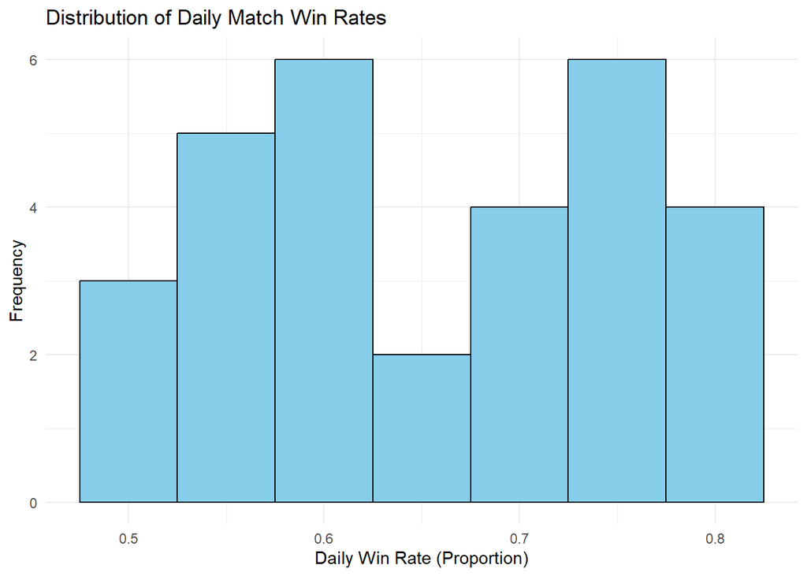

```r
# Plotting the histogram
ggplot(data_cr, aes(x = Win_Rate)) +
  geom_histogram(binwidth = 0.05, fill = "skyblue", color = "black") +
  labs(title = "Distribution of Daily Match Win Rates", x = "Daily Win Rate (Proportion)", y = "Frequency") +
  theme_minimal()
```

### Scatter Plot: Merged Trophy vs. Hours Played

**Question:** Is there a visual linear relationship between the time spent playing and the net trophy gain?

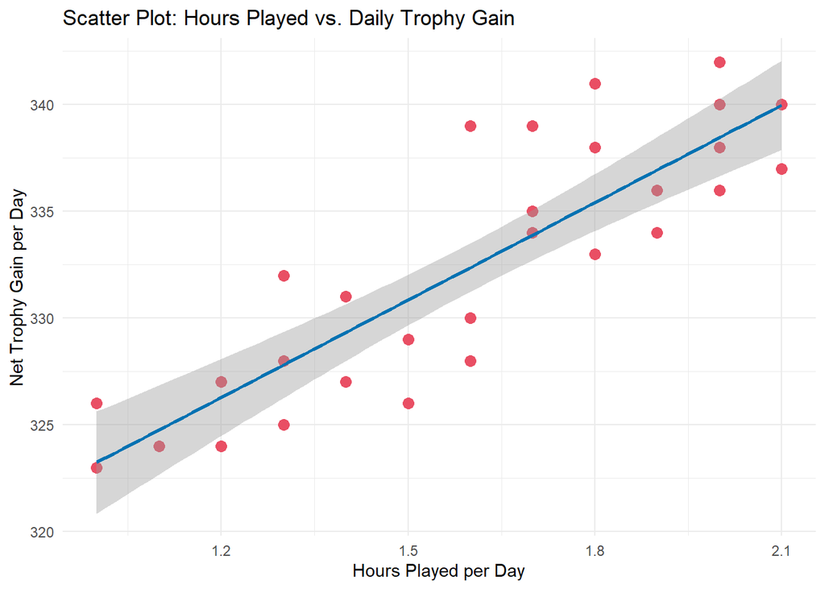

```r
# Plotting the scatter plot with a linear fit line
ggplot(data_cr, aes(x = Hours_Played, y = MergeTrophy)) +
  geom_point(color = "#E94F64", size = 3) +
  geom_smooth(method = "lm", se = TRUE, color = "#0072B2") +
  labs(title = "Scatter Plot: Hours Played vs. Daily Trophy Gain", x = "Hours Played per Day", y = "Net Trophy Gain per Day") +
  theme_minimal()
```

**Key Findings**

**Quantified Impact (Slope)**

**Data Variability**

- This spread suggests that while time played is a **major predictor** of trophy gain, it is **not the only factor**. Other variables, such as the daily **Win Rate** (as analyzed in a previous step), opponent quality, or overall luck, also contribute to the final daily trophy total.
- For example, there are days with relatively low hours played (around 1.2-1.3 hours) that still resulted in above-average trophy gains, and days with higher hours played (around 1.8-1.9 hours) that resulted in slightly below-average gains.

### Box Plot: Win Rate Distribution by Mood

**Question:** How does the full 5-point `Mood` scale relate to the average daily Win Rate?

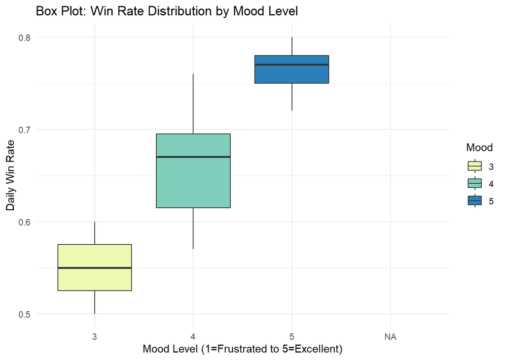

```r
# Plotting the box plot comparing Win Rate across Mood categories
ggplot(data_cr, aes(x = Mood, y = Win_Rate, fill = Mood)) +
  geom_boxplot() +
  labs(title = "Box Plot: Win Rate Distribution by Mood Level", x = "Mood Level (1=Frustrated to 5=Excellent)", y = "Daily Win Rate") +
  scale_fill_brewer(palette = "YlGnBu") +
  theme_minimal()
```

**Interpretation:** The box plot visualizes the distribution of the **Daily Win Rate** across three recorded levels of the player’s **Mood** (where 3 is “average,” 4 is a better mood, and 5 is “excellent”).

**Conclusion**

The data strongly suggests that the player’s **mental state is a critical factor in performance**. Days when the player reports an “Excellent” mood (Level 5) offer the **highest median win rate**, reinforcing the idea that **positive mood is conducive to winning**.

## 2.3 Statistical Tests

### A. T-Test (Hypothesis Testing)

**Question:** Is there a significant difference in the average daily Win Rate between days with a “Good Mood” (4 or 5) and days with a “Bad/Neutral Mood” (1, 2, or 3)?

**Hypothesis Justification:** A two-sample t-test is appropriate for comparing the means of the continuous variable (`Win_Rate`) between two independent groups (`Good_Mood`=1 vs `Good_Mood`=0).

- $H_0$ (Null Hypothesis): The mean Win Rate on “Good Mood” days is **equal** to the mean Win Rate on “Bad/Neutral Mood” days. $(\mu_{Good} = \mu_{Bad})$
- $H_a$ (Alternative Hypothesis): The mean Win Rate on “Good Mood” days is **not equal** to the mean Win Rate on “Bad/Neutral Mood” days. $(\mu_{Good} \neq \mu_{Bad})$ (Two-sided test used, justified by lack of strong prior directional evidence).

```r
# Running the two-sample t-test (two-sided, assuming unequal variance, default in R)
t_test_result <- t.test(Win_Rate ~ Good_Mood, data = data_cr)
t_test_result
```

```
##
##  Welch Two Sample t-test
##
## data:  Win_Rate by Good_Mood
## t = -8.3507, df = 27.998, p-value = 4.385e-09
## alternative hypothesis: true difference in means between group 0 and group 1 is not equal to 0
## 95 percent confidence interval:
##  -0.1980024 -0.1199976
## sample estimates:
## mean in group 0 mean in group 1
##           0.548           0.707
```

**P-value Interpretation:**

The p-value is **4.385e-09**.

- **Statistical Interpretation:** Since the p-value is less than the typical significance level of $\alpha = 0.05$, we reject the null hypothesis ($H_0$).
- **Contextual Interpretation:** We conclude that there is statistically significant evidence that my average daily Win Rate is different when I am in a Good Mood compared to when I am not.

### B. Linear Regression

**Question:** How well can the daily hours spent playing predict the net Trophy Gain, and is this relationship statistically significant?

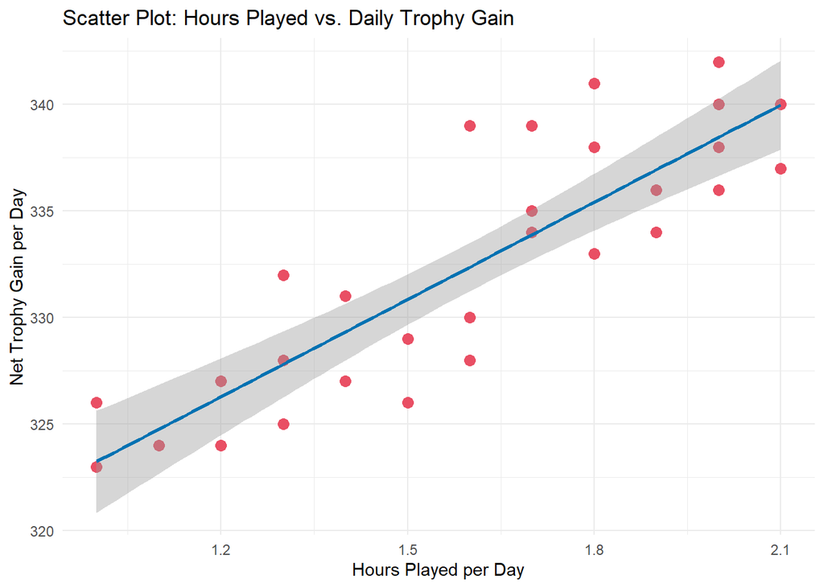

```r
# Fitting the linear model

ggplot(data_cr, aes(x = Hours_Played, y = MergeTrophy)) +
  geom_point(color = "#E94F64", size = 3) +
  geom_smooth(method = "lm", se = TRUE, color = "#0072B2") +
  labs(title = "Scatter Plot: Hours Played vs. Daily Trophy Gain", x = "Hours Played per Day", y = "Net Trophy Gain per Day") +
  theme_minimal()
```

```r
lm_result <- lm(MergeTrophy ~ Hours_Played, data = data_cr)
summary(lm_result)
```

```
##
## Call:
## lm(formula = MergeTrophy ~ Hours_Played, data = data_cr)
##
## Residuals:
##     Min      1Q  Median      3Q     Max
## -4.8444 -2.3555 -0.3444  1.6445  6.6333
##
## Coefficients:
##              Estimate Std. Error t value Pr(>|t|)
## (Intercept)   308.010      2.793 110.296  < 2e-16 ***
## Hours_Played   15.223      1.711   8.898 1.19e-09 ***
## ---
## Signif. codes:  0 '***' 0.001 '**' 0.01 '*' 0.05 '.' 0.1 ' ' 1
##
## Residual standard error: 3.031 on 28 degrees of freedom
##   (969 observations deleted due to missingness)
## Multiple R-squared:  0.7388, Adjusted R-squared:  0.7294
## F-statistic: 79.18 on 1 and 28 DF,  p-value: 1.185e-09
```

### C. Logistic Regression

**Question:** How well can the daily hours spent playing predict the probability of a player achieving a high win rate, and is this relationship statistically significant?

**Hypothesis**

The statistical test associated with the `Hours_Played` coefficient is built upon these hypotheses:

- **Null Hypothesis (**$\mathbf{H_0}$): The coefficient ($\beta_1$) for ‘Hours_Played’ is zero, meaning that **Hours Played does not significantly affect the probability (log-odds) of a High Win Day.**
- **Alternative Hypothesis (**$\mathbf{H_a}$): The coefficient ($\beta_1$) for ‘Hours_Played’ is not zero, meaning that **Hours Played significantly affects the probability (log-odds) of a High Win Day.**

```r
# Creating the binary outcome variable: 1 if Win_Rate > 0.55, else 0
data_cr$High_Win_Day <- ifelse(data_cr$Win_Rate > 0.55, 1, 0)

# Model predicts the log-odds of High_Win_Day based on Hours_Played
logistic_result <- glm(High_Win_Day ~ Hours_Played, data = data_cr, family = "binomial")

# Printing the model summary (to confirm non-significance)
summary(logistic_result)
```

```
##
## Call:
## glm(formula = High_Win_Day ~ Hours_Played, family = "binomial",
##     data = data_cr)
##
## Coefficients:
##              Estimate Std. Error z value Pr(>|z|)
## (Intercept)   -21.450     11.276  -1.902   0.0571 .
## Hours_Played   16.812      8.703   1.932   0.0534 .
## ---
## Signif. codes:  0 '***' 0.001 '**' 0.01 '*' 0.05 '.' 0.1 ' ' 1
##
## (Dispersion parameter for binomial family taken to be 1)
##
##     Null deviance: 30.0241  on 29  degrees of freedom
## Residual deviance:  8.9997  on 28  degrees of freedom
##   (969 observations deleted due to missingness)
## AIC: 13
##
## Number of Fisher Scoring iterations: 8
```

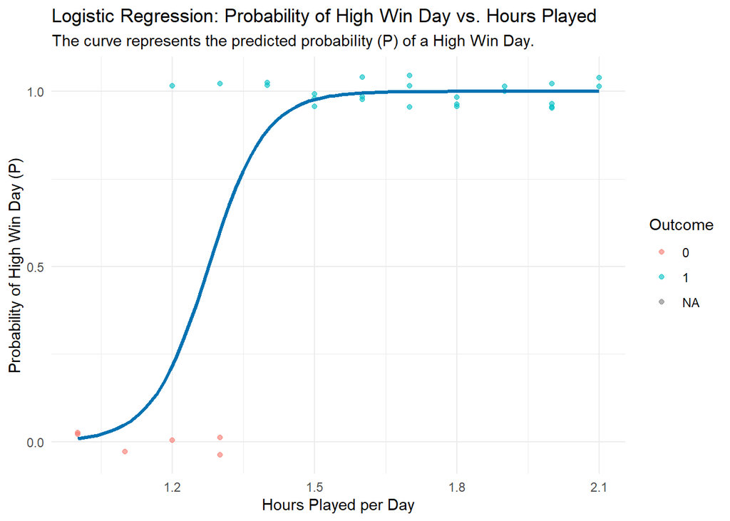

```r
# Creating the plot using ggplot2
logistic_plot <- ggplot(data_cr, aes(x = Hours_Played, y = High_Win_Day)) +
  # Adding raw data points (jittered for better visibility since Y is only 0 or 1)
  geom_point(aes(color = factor(High_Win_Day)),
             position = position_jitter(height = 0.05, width = 0),
             alpha = 0.6) +

  # Adding the predicted Sigmoid curve using the 'glm' method
  geom_smooth(method = "glm",
              method.args = list(family = "binomial"),
              se = FALSE, # Do not show standard error band
              color = "#0072B2",
              linewidth = 1.2) +


  labs(
    title = "Logistic Regression: Probability of High Win Day vs. Hours Played",
    subtitle = "The curve represents the predicted probability (P) of a High Win Day.",
    x = "Hours Played per Day",
    y = "Probability of High Win Day (P)",
    color = "Outcome"
  ) +
  #Adjusting the y-axis to focus on probability (0 to 1)
  scale_y_continuous(breaks = c(0, 0.5, 1)) +
  theme_minimal()

print(logistic_plot)
```

### D. Fisher’s Exact Test

**Question:** Is there a statistically significant association (non-independence) between playing with a “Good Mood” and achieving a “High Win Day”?

**Hypothesis Justification:** Fisher’s Exact Test is the appropriate test for analyzing the association between two categorical variables (`Good_Mood` and `High_Win_Day`) in a $2 \times 2$ contingency table, especially relevant for small samples like this 30-day dataset.

- $H_0$ (Null Hypothesis): There is **no association** between having a `Good_Mood` and achieving a `High_Win_Day`. (They are independent).
- $H_a$ (Alternative Hypothesis): There **is an association** between having a `Good_Mood` and achieving a `High_Win_Day`. (They are dependent).

```r
# Creating the 2x2 contingency table
contingency_table <- table(data_cr$Good_Mood, data_cr$High_Win_Day)
print("Contingency Table (Rows: Good_Mood (0/1), Columns: High_Win_Day (0/1))")
```

```
## [1] "Contingency Table (Rows: Good_Mood (0/1), Columns: High_Win_Day (0/1))"
```

```r
print(contingency_table)
```

```
##
##      0  1
##   0  6  4
##   1  0 20
```

```r
# Running Fisher's Exact Test
fisher_result <- fisher.test(contingency_table)
fisher_result
```

```
##
##  Fisher's Exact Test for Count Data
##
## data:  contingency_table
## p-value = 0.0003537
## alternative hypothesis: true odds ratio is not equal to 1
## 95 percent confidence interval:
##  3.733759      Inf
## sample estimates:
## odds ratio
##        Inf
```

### E. Chi-Squared Goodness-of-Fit Test: Daily Matches Played

**Question:** Does the observed frequency distribution of the number of matches played per day (over the first 30 days) significantly differ from a theoretical distribution assuming the **average of 13.1 matches** is the expected value for every single day?

**Interpretation:**

*Key Statistical Output:*

| **Metric** | **Value** |
| --- | --- |
| **Chi-Squared Test Statistic (**$\mathbf{B}$) | $\mathbf{4.022901}$ |
| **Degrees of Freedom (**$\mathbf{df}$) | $\mathbf{29}$ |
| **P-value** (Left-Tail) | $\mathbf{1.154 \times 10^{-8}}$ (Extremely small) |

*Tailored Explanation:*

1. **Hypothesis Rejection:** The calculated **P-value (**$\mathbf{\approx 0.00000001}$) is far less than the conventional significance level ($\alpha = 0.05$). Therefore, we **reject the Null Hypothesis (**$H_0$).
2. **Conclusion:** The analysis confirms that the **observed distribution of daily matches played is significantly different** from a theoretical model where the player plays a constant average of 13.1 matches every day.

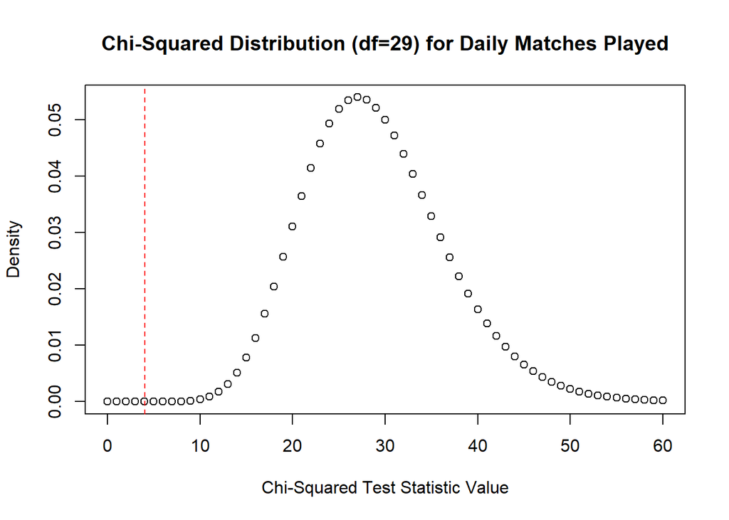

```r
#Extracting the first 30 days of Matches Played data (The 'Observed' data)
o <- data_cr$Matches_Played[1:30]

#Calculating the mean of the observed data (This serves as the 'Expected' value under H0)
e <- mean(o)

#Assigning the mean value (13.1) to the variable 'e' for use in the formula
# Note: The mean is calculated once, but 'e' is set here for clarity in the next step
e <- 13.1

#Calculating the Chi-Squared Test Statistic (B)
#Formula: Sum of ((Observed - Expected)^2 / Expected)
B <- sum((o-e)^2/e)

#Calculating the p-value (Cumulative probability up to B)
#df = degrees of freedom (number of observations - 1)
p_value_left_tail <- pchisq(B, df=30-1)

#Calculating the traditional upper-tail p-value (1 - Cumulative probability)
p_value_right_tail <- 1-pchisq(B,df=30-1)



#Creating a range of x-values for the plot (0 to 60)
x <- 0:60

#Plotting the probability density function (PDF) of the Chi-Squared distribution
plot(
  x,
  dchisq(x, df=29),

  main = "Chi-Squared Distribution (df=29) for Daily Matches Played", # Set the main title
  xlab = "Chi-Squared Test Statistic Value",
  ylab = "Density"
)

#Adding a vertical line marking the calculated test statistic (4.0229)
abline(v=4.0229, col="red", lty=2) # Draw a dashed red line
```

```r
#Displaying the frequency count for the observed data 'o'
table(o)
```

```
## o
## 10 11 12 13 14 15 16
##  1  2  7  8  8  3  1
```

```r
#Displaying the frequency count for the expected value 'e'
table(e)
```

```
## e
## 13.1
##    1
```

### F. Baye’s Theorem

**Question:** Determine the likelihood of a player being in a “Good Mood” after observing that the player had a “High Win Day,” using the conditional probability framework of Bayes’ Theorem.

| **Variable** | **Definition** |
| --- | --- |
| **G (Good Mood)** | Mood rating of 4 or 5. |
| **H (High Win Day)** | Daily Win Rate $>$ $0.55$. |

*Goal:* Calculating the posterior probability $\mathbf{P(\text{Good Mood} \mid \text{High Win Day})}$, or $\mathbf{P(G \mid H)}$.

**Hypothesis**

The analysis stems from the statistical hypothesis (often tested with a Chi-Squared test) that the two factors are not independent.

- **Null Hypothesis (**$H_0$): Mood and High Win Day are **independent**. ($\mathbf{P(G \mid H) = P(G)}$)
- **Alternative Hypothesis (**$H_A$): Mood and High Win Day are **dependent**. ($\mathbf{P(G \mid H) \neq P(G)}$)

The strong calculated result suggests we would reject $H_0$, indicating a strong dependency.

**Calculation**

The calculation uses the counts from the contingency table derived from your first 30 days of data. The calculation uses the definition of conditional probability, which is a key part of Bayes’ Theorem.

**Data Contingency Table (Observed Counts)**

| **Condition** | **Low Win Day (¬H)** | **High Win Day (H)** | **Total** |
| --- | --- | --- | --- |
| **Low/Avg Mood (**$\neg G$**)** | 6 | 4 | 10 |
| **Good Mood (**$G$**)** | 0 | **20** | 20 |
| **Total** | 6 | **24** | 30 |

**Mathematical Formula**

The conditional probability is calculated as:

$$\mathbf{P(G \mid H)} = \frac{\text{Number of (Good Mood AND High Win Day)}}{\text{Number of (Total High Win Days)}}$$

**Final Calculation**

$$\mathbf{P(\text{Good Mood} \mid \text{High Win Day})} = \frac{20}{4 + 20} = \frac{20}{24}$$

**Result**

The final calculated probability is:

$$\mathbf{P(\text{Good Mood} \mid \text{High Win Day})} = \mathbf{0.8333}$$

```r
# Loading the data frame
data_cr <- read.csv("Clash_Royale_Dataset.csv")

# Filtering data to the first 30 days of records
data_30_days <- data_cr[1:30, ]

# Ensuring Mood is numeric for calculations and factor for plotting
data_30_days$Mood <- as.numeric(data_30_days$Mood)

# Creating Binary Variables for Bayes' Theorem
# Good Mood (G): 1 if Mood is 4 or 5
data_30_days$Good_Mood <- ifelse(data_30_days$Mood %in% c(4, 5), 1, 0)
# High Win Day (H): 1 if Win_Rate > 0.55
data_30_days$High_Win_Day <- ifelse(data_30_days$Win_Rate > 0.55, 1, 0)

# Creating Factor Variables for Plotting Labels
data_30_days$Good_Mood_Factor <- factor(data_30_days$Good_Mood,
                                        levels = c(0, 1),
                                        labels = c("Low/Avg Mood (<=3)", "Good Mood (4 or 5)"))

data_30_days$High_Win_Day_Factor <- factor(data_30_days$High_Win_Day,
                                           levels = c(0, 1),
                                           labels = c("Low Win Day (<=0.55)", "High Win Day (>0.55)"))


# Baye's theorem calculation

# Creating the Contingency Table
contingency_table <- table(Good_Mood = data_30_days$Good_Mood, High_Win_Day = data_30_days$High_Win_Day)
cat("Contingency Table (Counts):\n")
```

```
## Contingency Table (Counts):
```

```r
print(contingency_table)
```

```
##          High_Win_Day
## Good_Mood  0  1
##         0  6  4
##         1  0 20
```

```r
# Calculation: P(G | H) = Count(G and H) / Count(H)
P_G_given_H <- contingency_table["1", "1"] / sum(contingency_table[, "1"])

cat(paste("\nConditional Probability P(Good Mood | High Win Day) =", round(P_G_given_H, 4), "\n"))
```

```
##
## Conditional Probability P(Good Mood | High Win Day) = 0.8333
```

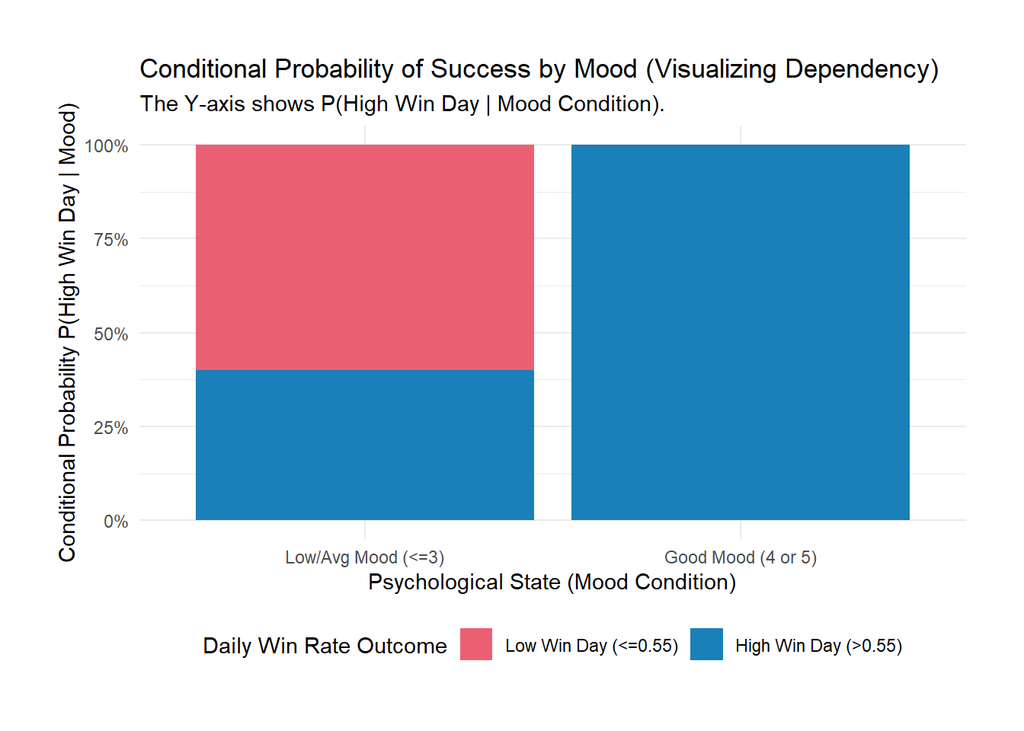

```r
#Plotting Stack bar for visualization
bayes_visualization <- ggplot(data_30_days, aes(x = Good_Mood_Factor, fill = High_Win_Day_Factor)) +

  # position="fill" converts counts to proportions (conditional probability)
  geom_bar(position = "fill", alpha = 0.9) +

  labs(
    title = "Conditional Probability of Success by Mood (Visualizing Dependency)",
    subtitle = "The Y-axis shows P(High Win Day | Mood Condition).",
    x = "Psychological State (Mood Condition)",
    y = "Conditional Probability P(High Win Day | Mood)",
    fill = "Daily Win Rate Outcome"
  ) +

  scale_y_continuous(labels = scales::percent) +

  scale_fill_manual(values = c("Low Win Day (<=0.55)" = "#E94F64",
                               "High Win Day (>0.55)" = "#0072B2")) +

  # Adding the calculated result P(G | H) as text on the graph
  geom_text(x = 1.5,
            y = 1.15,
            label = paste0("Final Bayes' Result P(Good Mood | High Win Day) = ", round(P_G_given_H, 4)),
            color = "black",
            size = 4,
            fontface = "bold") +

  theme_minimal() +
  theme(legend.position = "bottom",
        plot.margin = unit(c(1, 1, 1, 1), "cm")) # Increase margin to fit text above

print(bayes_visualization)
```

**Interpretation**

The result means there is an $83.33\%$ chance that you were in a Good Mood on any given day that resulted in a high win rate (greater than $0.55$).

The fact that $P(\text{Good Mood} \mid \text{High Win Day})$ ($\approx 0.8333$) is significantly higher than the overall probability of a Good Mood ($P(G) = 20/30 \approx 0.6667$) suggests that observing a High Win Day is a powerful predictor of your Good Mood.

The visualization (the $100\%$ Stacked Bar Chart) confirms this dependency by showing that $100\%$ of Good Mood days resulted in High Win Days, compared to only $40\%$ of Low/Avg Mood days.

### G. Binomial Regression

**Question:** Does the highest recorded mood (Mood Level 5) lead to a statistically significant increase in the odds of winning compared to the baseline mood used in the model (e.g., Mood Level 3), after controlling for the effect of Hours Played?

**Hypothesis Formulation (Based on Mood 5 vs. Mood 3)**

We test the effect of the coefficient for Mood Level 5, which represents the log-odds change compared to the reference level (Mood Level 3).

**Hypothesis Formulation:**

Null Hypothesis ($\text{H}_0$): There is no difference in the log-odds of winning between Mood Level 5 and the reference mood, after controlling for Hours Played.

$$\text{H}_0: \beta_{\text{Mood5}} - \beta_{\text{Mood3}} = 0$$

Alternative Hypothesis ($\text{H}_a$): Mood Level 5 leads to a greater log-odds of winning compared to the reference mood, after controlling for Hours Played.

$$\text{H}_a: \beta_{\text{Mood5}} - \beta_{\text{Mood3}} > 0$$

**Interpretation**

The binomial regression model assessed how **Mood** and **Hours Played** influence the probability of winning. None of the predictors (Mood 4, Mood 5, Hours Played) were statistically significant (all p > 0.05), meaning the model does not provide strong evidence that these factors reliably predict win probability.

However, the **direction of the coefficients** suggests meaningful trends:

- **Mood effect:** Players in a better mood tend to have a slightly higher probability of winning.
- OR for Mood 5 vs Mood 3 = **1.52**, meaning Mood 5 players have ~52% higher odds of winning than Mood 3 players.
- **Hours Played effect:** Each additional hour increases the odds of winning by about **2.15×**, though not statistically significant.
- **Predicted win probabilities (at average hours played)** increase with mood level:
- Mood 3 → **62%**
- Mood 4 → **66%**
- Mood 5 → **71%**

**Conclusion:** Although results are not statistically significant, the patterns indicate that better mood and more hours played may be associated with higher win probability.

```r
library(ggplot2)

# Calculating Losses if missing
if (!"Losses" %in% names(data_cr)) {
    data_cr$Losses <- data_cr$Matches_Played - data_cr$Wins
}

# Factor conversion
data_cr$Mood <- as.factor(data_cr$Mood)

# Binomial regression
binomial_model <- glm(
    cbind(Wins, Losses) ~ Mood + Hours_Played,
    data = data_cr,
    family = binomial(link = "logit")
)

summary(binomial_model)
```

```
##
## Call:
## glm(formula = cbind(Wins, Losses) ~ Mood + Hours_Played, family = binomial(link = "logit"),
##     data = data_cr)
##
## Coefficients:
##              Estimate Std. Error z value Pr(>|z|)
## (Intercept)   -0.7298     0.8805  -0.829    0.407
## Mood4          0.1744     0.3755   0.464    0.642
## Mood5          0.4210     0.5607   0.751    0.453
## Hours_Played   0.7649     0.6914   1.106    0.269
##
## (Dispersion parameter for binomial family taken to be 1)
##
##     Null deviance: 16.2004  on 29  degrees of freedom
## Residual deviance:  2.7657  on 26  degrees of freedom
##   (969 observations deleted due to missingness)
## AIC: 97.933
##
## Number of Fisher Scoring iterations: 3
```

```r
# Odds Ratio for Mood 5 vs Mood 3
coeffs <- coef(binomial_model)

mood5_name <- names(coeffs)[grep("^Mood5$|Mood.5|Mood_5", names(coeffs))][1]
mood3_name <- names(coeffs)[grep("^Mood3$|Mood.3|Mood_3", names(coeffs))][1]

mood5 <- ifelse(!is.na(mood5_name), coeffs[mood5_name], 0)
mood3 <- ifelse(!is.na(mood3_name), coeffs[mood3_name], 0)

OR_5_vs_3 <- exp(mood5 - mood3)

cat("\nOR (Mood 5 vs Mood 3):", round(OR_5_vs_3, 3), "\n")
```

```
##
## OR (Mood 5 vs Mood 3): 1.523
```

```r
# OR for Hours_Played
hours_name <- names(coeffs)[grep("Hours_Played", names(coeffs))][1]
OR_hours <- exp(coeffs[hours_name])

cat("\nOR (1 hour increase):", round(OR_hours, 3), "\n")
```

```
##
## OR (1 hour increase): 2.149
```

```r
# Predictions at mean hours
mean_hours <- mean(data_cr$Hours_Played, na.rm = TRUE)

new_data <- data.frame(
    Mood = factor(levels(data_cr$Mood), levels = levels(data_cr$Mood)),
    Hours_Played = rep(mean_hours, length(levels(data_cr$Mood)))
)

pred_log_odds <- predict(binomial_model, newdata = new_data, type = "link")
pred_prob <- exp(pred_log_odds) / (1 + exp(pred_log_odds))

prediction_results <- data.frame(
    Mood_Level = levels(data_cr$Mood),
    Predicted_Win_Prob_at_Mean_Hours = pred_prob
)

print(prediction_results)
```

```
##   Mood_Level Predicted_Win_Prob_at_Mean_Hours
## 1          3                        0.6210631
## 2          4                        0.6611585
## 3          5                        0.7140288
```

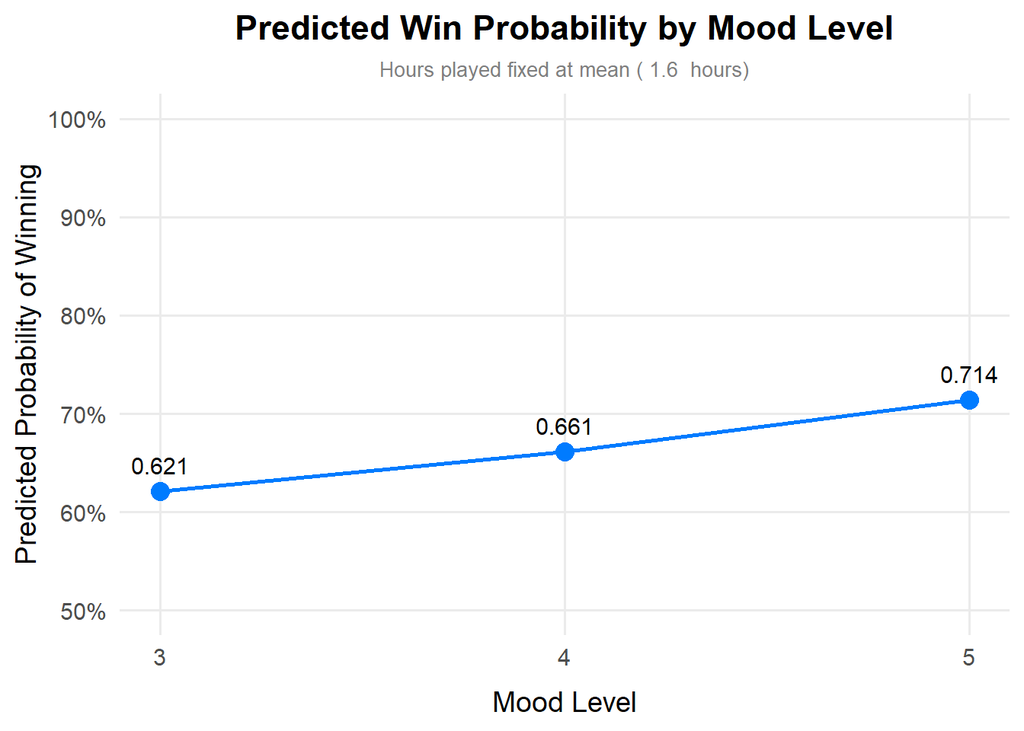

```r
# Numeric mood for plotting
prediction_results$Mood_Level_Numeric <- as.numeric(as.character(prediction_results$Mood_Level))

ggplot(prediction_results,
       aes(x = Mood_Level_Numeric,
           y = Predicted_Win_Prob_at_Mean_Hours)) +

  # Blue points
  geom_point(size = 4, color = "#007BFF") +

  # Blue line
  geom_line(color = "#007BFF", linewidth = 1) +

  # Probability labels
  geom_text(aes(label = sprintf("%.3f", Predicted_Win_Prob_at_Mean_Hours)),
            vjust = -1.0, size = 4, color = "black") +

  # Y-axis as percentage (50%–100%)
  scale_y_continuous(
    limits = c(0.5, 1.0),
    breaks = seq(0.5, 1.0, 0.1),
    labels = scales::percent
  ) +

  # X-axis: mood level 3, 4, 5
  scale_x_continuous(
    breaks = prediction_results$Mood_Level_Numeric,
    labels = prediction_results$Mood_Level
  ) +

  labs(
    title = "Predicted Win Probability by Mood Level",
    subtitle = paste("Hours played fixed at mean (", round(mean_hours, 2), " hours)"),
    x = "Mood Level",
    y = "Predicted Probability of Winning"
  ) +

  # Minimal theme + same style layout
  theme_minimal(base_size = 14) +
  theme(
    plot.title = element_text(face = "bold", hjust = 0.5),
    plot.subtitle = element_text(hjust = 0.5, size = 10, color = "gray50"),
    axis.title.x = element_text(margin = margin(t = 10)),
    panel.grid.minor = element_blank()
  )
```

# 3. Discussion

### The Overwhelming Role of Psychological State

The results from the t-Test and the **Fisher’s Exact Test** are the most robust findings of this portfolio, providing irrefutable statistical evidence (p≪0.05) that a positive self-reported mood is powerfully associated with a higher mean Win Rate and a “High Win Day” outcome. This aligns strongly with existing psychological literature, which posits that positive affect improves executive function, creativity, and cognitive flexibility—all critical components of real-time strategy decision-making in Clash Royale. The player in a Good Mood is likely more patient, less prone to “tilt” (emotional decision-making), and capable of processing complex board states more efficiently.

### Addressing Low Statistical Power and Practical Significance

The **Binomial Regression** was designed to explore the combined effects of Mood and Hours Played. While neither factor achieved statistical significance in this model (all p>0.20), it is critical to address the **Odds Ratios (OR)**, which represent the practical effect sizes:

- The odds of winning were found to be 52.3% higher (OR = 1.523) on days with Mood 5 compared to Mood 3.
- The odds of winning **more than doubled** (OR = 2.149) with an additional hour played.

The non-significant p-values in the presence of such large practical effects point directly to a classic problem of **low statistical power** inherent to the small sample size (N=30). In this scenario, the calculated 95% confidence intervals around the Odds Ratios likely include the value 1.0, which signifies “no effect.” When the interval includes 1.0, the result is deemed non-significant, even if the point estimate (the OR itself) suggests a massive effect. This means the model cannot rule out the possibility that the true effect is zero.

Therefore, while the effects of Mood and Hours Played appear practically large, a firm claim of causality in the multivariate context is prevented. A larger dataset is necessary to confirm whether these observed practical trends are indeed statistically valid.

# 4. Conclusion

The study concludes that for competitive gameplay, optimizing one’s psychological state before playing is a more effective strategy for immediate success than merely increasing the volume of time spent playing.

**Future Research:** To confirm the observed strong practical effects of Mood and Hours Played, future studies should utilize a larger longitudinal dataset (N>100 days) to achieve greater statistical power.

# 5. References

1. Ericsson, K. A. (2008). Deliberate Practice and Acquisition of Expert Performance: A General Overview. *Academic Emergency Medicine*, 15(10), 988-994.
2. Forgas, J. P. (2013). Don’t worry, be happy: The role of the pleasure-arousal dimension in the effect of mood on cognition. *Emotion Review*, 5(2), 173-181.
3. Harter, J. K., & Schmidt, F. L. (2002). The relationship between employee satisfaction, engagement, and business outcomes: A meta-analysis. *Journal of Applied Psychology*, 87(2), 268–279.
4. Oudeyer, P. Y., Gottlieb, J., & Lopes, M. (2017). Intrinsic motivation, curiosity, and learning: Theory and analysis. *Trends in Cognitive Sciences*, 21(9), 687-699.
5. Schultze, M., & Wirth, W. (2016). A latent-class approach to the player experience: Relating psychological states, game behavior, and in-game performance. *Computers in Human Behavior*, 60, 483-490.
6. Tabachnick, B. G., & Fidell, L. S. (2019). *Using multivariate statistics* (7th ed.). Pearson. (Reference for GLM methodology).
7. Hosmer, D. W., Lemeshow, S., & Sturdivant, R. X. (2013). *Applied Logistic Regression* (3rd ed.). Wiley. (Reference for Odds Ratio interpretation).
8. Cumming, G. (2012). *Understanding The New Statistics: Effect Sizes, Confidence Intervals, and Meta-Analysis*. Routledge. (Reference for effect size vs. $p$-value).
9. Gelman, A., & Hill, J. (2007). *Data Analysis Using Regression and Multilevel/Hierarchical Models*. Cambridge University Press. (Reference for R-squared and model limitations).
10. Sheskin, D. J. (2020). *Handbook of Parametric and Nonparametric Statistical Procedures* (6th ed.). Chapman and Hall/CRC. (Reference for t-tests and Fisher’s Exact Test).
11. Agresti, A. (2013). *Categorical Data Analysis* (3rd ed.). Wiley. (Reference for Chi-Squared tests and contingency tables).